# Marketplace Revenue Risk & Financial Stability Analysis

Liyuan Wan

2026-04-11

## Setup

This section loads required libraries and connects to the database.

```r
library(DBI)
library(RPostgres)
library(ggplot2)
library(dplyr)
library(ineq)

con <- dbConnect(
  RPostgres::Postgres(),
  dbname = "leowan34",
  host = "localhost",
  port = 5332,
  user = "leowan34",
  password = Sys.getenv("PG_PASSWORD")
)
```

## Data Loading

Loading the datasets from the database for analysis.

```r
monthly  <- dbReadTable(con, "monthly_revenue")
customer <- dbReadTable(con, "customer_revenue_decile")
payment  <- dbReadTable(con, "order_payment_structure")
state    <- dbReadTable(con, "state_revenue")
```

## Revenue Stability

This section evaluates the volatility of monthly revenue and short-term growth dynamics to assess how predictable cash flows are over time.

```r
sd_rev   <- sd(monthly$monthly_revenue, na.rm = TRUE)
mean_rev <- mean(monthly$monthly_revenue, na.rm = TRUE)
cv_rev   <- sd_rev / mean_rev

cv_rev
```

```
## [1] 0.4171597
```

The coefficient of variation (CV = 0.42) indicates moderate revenue volatility. While the overall trend is upward, revenue is not yet stable enough for reliable short-term forecasting — a meaningful consideration for cash flow planning and budgeting.

```r
monthly <- monthly %>%
  arrange(month) %>%
  mutate(
    mom_growth = (monthly_revenue - lag(monthly_revenue)) / lag(monthly_revenue)
  )

monthly_growth <- monthly %>%
  filter(!is.na(mom_growth))

sd(monthly$mom_growth, na.rm = TRUE)
```

```
## [1] 0.3239884
```

Month-over-month growth shows high standard deviation, reflecting an unstable short-term performance pattern. Large swings between consecutive months suggest the business has not yet achieved consistent growth momentum.

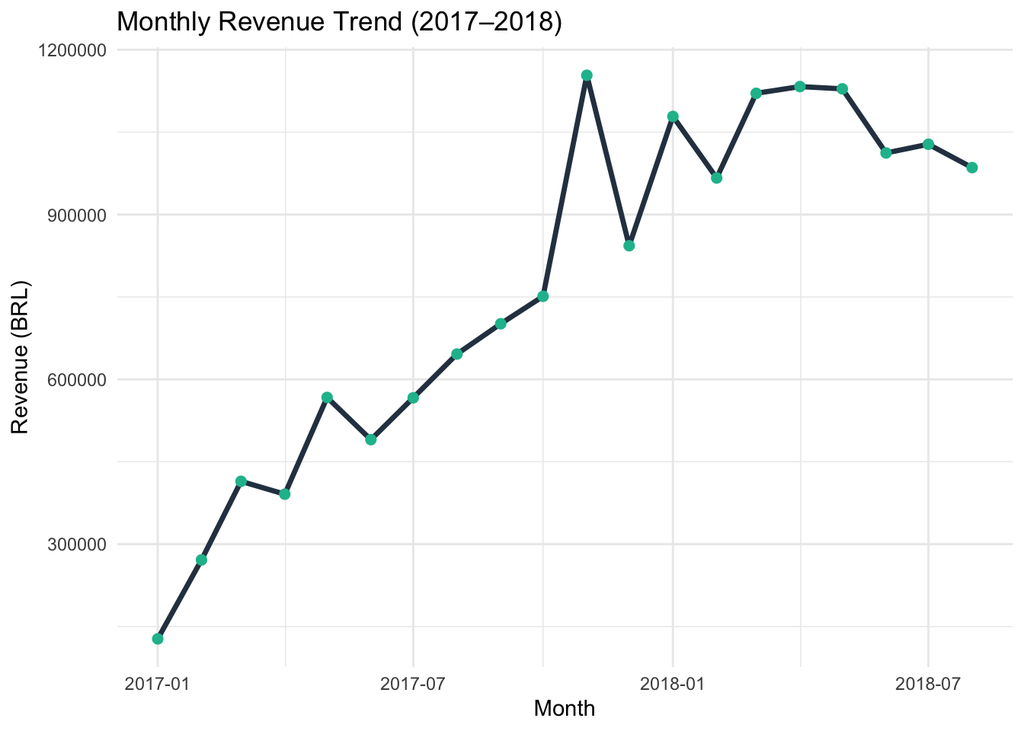

```r
ggplot(monthly, aes(x = month, y = monthly_revenue)) +
  geom_line(linewidth = 1.2, color = "#2C3E50") +
  geom_point(size = 2, color = "#1ABC9C") +
  labs(
    title = "Monthly Revenue Trend (2017–2018)",
    x = "Month",
    y = "Revenue (BRL)"
  ) +
  theme_minimal()
```

Revenue grew steadily through 2017, with a sharp spike in late 2017 followed by elevated but volatile performance through 2018. The spike warrants further investigation — it may reflect a seasonal event or promotional campaign rather than organic growth.

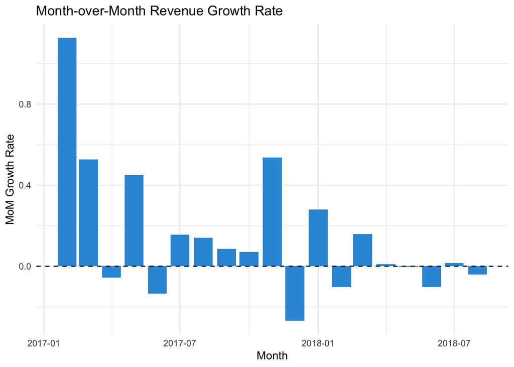

```r
ggplot(monthly_growth, aes(x = month, y = mom_growth)) +
  geom_col(fill = "#3498DB") +
  geom_hline(yintercept = 0, linetype = "dashed") +
  labs(
    title = "Month-over-Month Revenue Growth Rate",
    x = "Month",
    y = "MoM Growth Rate"
  ) +
  theme_minimal()
```

MoM growth is highly uneven — several months of strong positive growth are offset by multiple months of decline. This pattern is consistent with a marketplace still in an early growth stage, subject to demand shocks and inconsistent order volume.

## Geographic Concentration

This section examines the degree of geographic concentration in revenue and the risk of over-reliance on specific regions.

```r
state <- state %>%
  arrange(desc(total_revenue)) %>%
  mutate(
    revenue_share = total_revenue / sum(total_revenue)
  )
```

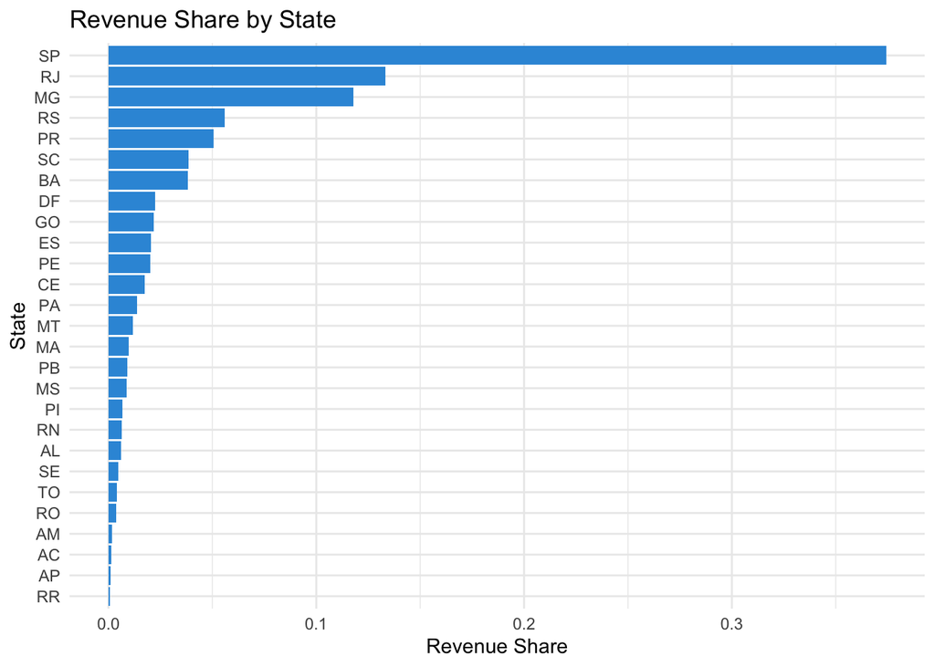

```r
ggplot(state, aes(x = reorder(customer_state, revenue_share),
                  y = revenue_share)) +
  geom_col(fill = "#3498DB") +
  coord_flip() +
  labs(
    title = "Revenue Share by State",
    x = "State",
    y = "Revenue Share"
  ) +
  theme_minimal()
```

Revenue is highly concentrated in a small number of states. São Paulo (SP) alone accounts for approximately 37% of total revenue, followed by Rio de Janeiro (RJ) at ~13% and Minas Gerais (MG) at ~12%. The remaining 24 states collectively contribute less than 40%, indicating that the marketplace’s financial performance is closely tied to conditions in Southeast Brazil.

```r
hhi <- sum(state$revenue_share^2)
hhi
```

```
## [1] 0.1831757
```

The Herfindahl-Hirschman Index (HHI = 0.183) reflects a moderate level of geographic concentration. While the market is not monopolistically concentrated, the heavy dependence on SP introduces regional risk — any economic disruption, logistics issue, or regulatory change in São Paulo could materially impact overall revenue.

## Customer Concentration

This section measures how revenue is distributed across customers and whether a small share of customers contributes a disproportionate share of revenue.

```r
decile_summary <- customer %>%
  group_by(decile) %>%
  summarise(
    customer_count = n(),
    total_revenue  = sum(total_revenue),
    .groups = "drop"
  ) %>%
  arrange(decile) %>%
  mutate(
    revenue_share = total_revenue / sum(total_revenue)
  )
```

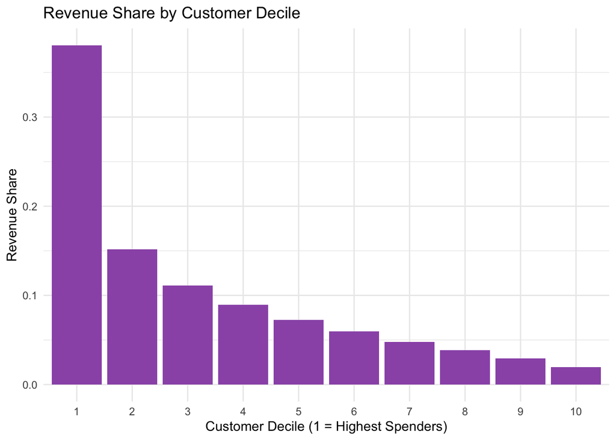

```r
ggplot(decile_summary, aes(x = factor(decile), y = revenue_share)) +
  geom_col(fill = "#9B59B6") +
  labs(
    title = "Revenue Share by Customer Decile",
    x    = "Customer Decile (1 = Highest Spenders)",
    y    = "Revenue Share"
  ) +
  theme_minimal()
```

Revenue is heavily concentrated among the highest-value customers. The top decile alone contributes approximately 38% of total revenue, and the top three deciles together account for roughly 64%. This steep drop-off across deciles signals a high degree of customer dependency — losing a small number of high-value customers could have an outsized impact on total revenue.

```r
customer_sort <- customer %>%
  arrange(total_revenue) %>%
  mutate(
    cum_customer = row_number() / n(),
    cum_revenue  = cumsum(total_revenue) / sum(total_revenue)
  )
```

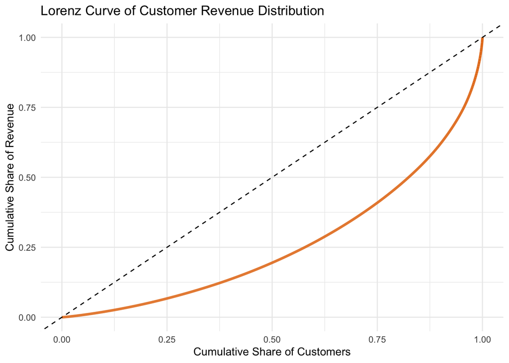

```r
ggplot(customer_sort, aes(x = cum_customer, y = cum_revenue)) +
  geom_line(color = "#E67E22", linewidth = 1.2) +
  geom_abline(linetype = "dashed") +
  labs(
    title = "Lorenz Curve of Customer Revenue Distribution",
    x = "Cumulative Share of Customers",
    y = "Cumulative Share of Revenue"
  ) +
  theme_minimal()
```

The Lorenz curve deviates substantially from the line of perfect equality, confirming a highly unequal distribution of revenue across the customer base.

```r
gini <- ineq(customer$total_revenue, type = "Gini")
gini
```

```
## [1] 0.4749423
```

The Gini coefficient of 0.475 indicates a moderate-to-high level of customer revenue inequality. This is consistent with typical marketplace dynamics where a small cohort of repeat, high-value buyers drives the majority of revenue — but also represents a concentration risk if those customers churn.

## Liquidity Risk

This section evaluates whether the payment structure could create cash flow timing risk for the business.

```r
payment_summary <- payment %>%
  group_by(payment_type) %>%
  summarise(
    order_count   = n(),
    total_revenue = sum(order_total),
    .groups = "drop"
  ) %>%
  mutate(
    order_share   = order_count / sum(order_count),
    revenue_share = total_revenue / sum(total_revenue)
  )
```

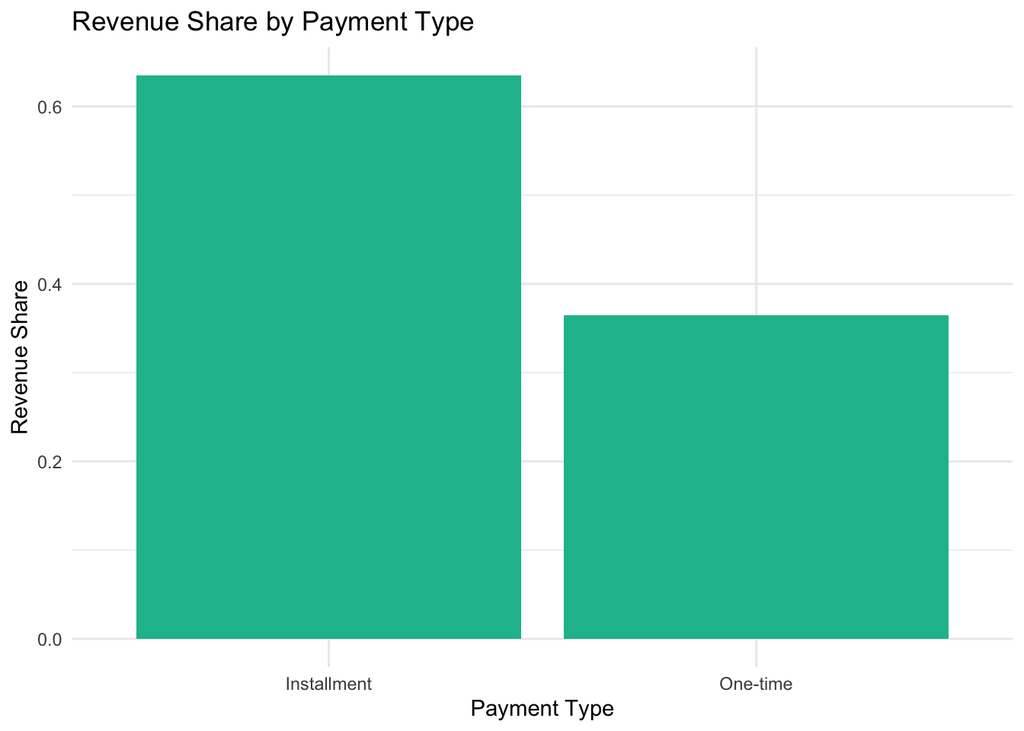

```r
ggplot(payment_summary, aes(x = payment_type, y = revenue_share)) +
  geom_col(fill = "#1ABC9C") +
  labs(
    title = "Revenue Share by Payment Type",
    x = "Payment Type",
    y = "Revenue Share"
  ) +
  theme_minimal()
```

Installment payments account for a significantly larger share of revenue than one-time payments. This means cash is collected incrementally over time rather than upfront, creating a structural gap between when revenue is recognized and when it is actually received.

```r
weighted_installment <- sum(payment$max_installments * payment$order_total) /
  sum(payment$order_total)

weighted_installment
```

```
## [1] 4.117279
```

The revenue-weighted average installment count is approximately 4.12, meaning that on average, each order’s payment is spread across more than four installments. This installment-heavy structure implies that a meaningful portion of recognized revenue will only be collected weeks to months after the transaction — a liquidity timing risk that should be reflected in working capital planning.